# INTRODUCTION

In response to continued demand for creative tools in an increasingly digital world, our company recently launched a new line of office stationery designed to support brainstorming and enhance productivity. To determine the most effective way to promote this new product line, we implemented and tested three distinct sales strategies: Email, Phone Call, and a combined Email + Call approach.

The objective of this analysis is to evaluate the performance of each sales method in terms of customer engagement, sales conversion, and cost-efficiency. This report outlines the steps taken for data validation and cleaning, presents the findings from exploratory data analysis, introduces a key business metric to track performance, and provides actionable recommendations based on the insights.

By applying data-driven evaluation to our sales approach, this report aims to guide future strategy and help ensure the long-term success and scalability of the new product line.

```python
import pandas as pd
import matplotlib.pyplot as plt
import seaborn as sns
import plotly.express as px
import datetime
import plotly.graph_objects as go
from plotly.graph_objects import Figure
from plotly.subplots import make_subplots
import plotly.io as pio
pio.renderers.default = 'notebook_connected'
```

# IMPORTING DATA AND DATA VALIDATION

Dimension of the original dataset: 15000 rows, 8 columns.

- The `week` column contains integer values from 1-6 no null values. No changes to this column were necessary.
- The `sales_method` column contains 5 different unique values (Email, Call, Email + Call, em + call, email) and no null values. The column should only contain 3 unique values corresponding to each type of sales method and 2 others are just variations. The column is changed to only contain the following 3 different value types corresponding to each alternate sales method: Email, Call, Email + Call.
- The `customer_id` column contains all unique records for each customer and had no missing values. No changes to this column were required.
- The `nb_sold` column contains numerical data of the quantity of new products sold. Upon inspection using a boxplot, no extreme outlier is found, so no change is necessary.
- The `revenue` column had 1074 null values. It consitutes 7.16% of the total observations which exceeds the 5% threshold. So, the best approach is to carry out an imputation of the mean value of the `revenue` column by subgroups (`sales_method`).
- The `years_as_customer` column has 0 missing values, however we had 2 rows with invalid values. Since our company was founded in 1984, the maximum amount of years we could have any given customer is 39. Two rows had values with 47 and 63, which is impossible. I assume this was just a mistake in data entry, and the 2 observations are discarded as it consitutes a minute portion of the whole dataset.
- The `nb_site_visit`s column has 0 missing values and all data is valid. No changes needed to be made to this column
- The `state` The column has 0 missing values and 50 unique values corresponding to each state. No changes need to be made to this column

Finally after all the data validation and cleaning I checked for any duplicate rows and found none. After cleaning and validating the data our dataset contains 14998 rows and 8 columns with 0 missing values.

```python
#Import data
df = pd.read_csv('product_sales.csv')

df.head()
```

|  | week | sales_method | customer_id | nb_sold | revenue | years_as_customer | nb_site_visits | state |
| --- | --- | --- | --- | --- | --- | --- | --- | --- |
| 0 | 2 | Email | 2e72d641-95ac-497b-bbf8-4861764a7097 | 10 | NaN | 0 | 24 | Arizona |
| 1 | 6 | Email + Call | 3998a98d-70f5-44f7-942e-789bb8ad2fe7 | 15 | 225.47 | 1 | 28 | Kansas |
| 2 | 5 | Call | d1de9884-8059-4065-b10f-86eef57e4a44 | 11 | 52.55 | 6 | 26 | Wisconsin |
| 3 | 4 | Email | 78aa75a4-ffeb-4817-b1d0-2f030783c5d7 | 11 | NaN | 3 | 25 | Indiana |
| 4 | 3 | Email | 10e6d446-10a5-42e5-8210-1b5438f70922 | 9 | 90.49 | 0 | 28 | Illinois |

The dataset has 15000 rows and 8 columns.

```python
df.shape
```

```
(15000, 8)
```

```python
df.info()
```

```
<class 'pandas.core.frame.DataFrame'>
RangeIndex: 15000 entries, 0 to 14999
Data columns (total 8 columns):
 #   Column             Non-Null Count  Dtype
---  ------             --------------  -----
 0   week               15000 non-null  int64
 1   sales_method       15000 non-null  object
 2   customer_id        15000 non-null  object
 3   nb_sold            15000 non-null  int64
 4   revenue            13926 non-null  float64
 5   years_as_customer  15000 non-null  int64
 6   nb_site_visits     15000 non-null  int64
 7   state              15000 non-null  object
dtypes: float64(1), int64(4), object(3)
memory usage: 937.6+ KB
```

All columns of the dataset has no null values except the revenue column with 1074 null values.

```python
# Check number of nulls in each columns
print(df.isna().sum())
```

```
week                    0
sales_method            0
customer_id             0
nb_sold                 0
revenue              1074
years_as_customer       0
nb_site_visits          0
state                   0
dtype: int64
```

Which is 7.16% of the observations of the revenue column. Since it is larger than the 5% threshold,the null values cannot be discarded. So, imputation of mean by subgroup will be used to deal with the null values in the revenue column.

```python
print(df.isna().sum()/df.shape[0] * 100)
```

```
week                 0.00
sales_method         0.00
customer_id          0.00
nb_sold              0.00
revenue              7.16
years_as_customer    0.00
nb_site_visits       0.00
state                0.00
dtype: float64
```

```python
# Imputation of 'revenue' column by subgroup mean
revdict = df.groupby("sales_method")['revenue'].mean().to_dict()
df['revenue'] = df.groupby("sales_method")['revenue'].fillna(df['sales_method'].map(revdict))
print(df.isna().sum())
```

```
week                 0
sales_method         0
customer_id          0
nb_sold              0
revenue              0
years_as_customer    0
nb_site_visits       0
state                0
dtype: int64
```

There are repeated categories in the sales_method column but with different spellings and capitalization. Other variations are corrected to only 3 groups: Email, Call, Email + Call.

```python
print(df['sales_method'].value_counts())
```

```
Email           7456
Call            4962
Email + Call    2549
em + call         23
email             10
Name: sales_method, dtype: int64
```

```python
#Replacing 'email' with 'Email' and 'call' with 'Call'
df['sales_method'] = df['sales_method'].replace({'email': 'Email', 'call': 'Call', 'em + call': 'Email + Call'})
print()
print(df['sales_method'].value_counts())
```

```
Email           7466
Call            4962
Email + Call    2572
Name: sales_method, dtype: int64
```

Checking the year_as_customer column, 2 columns with years being a customer exceeding the age of the company will be discarded as they are considered as errors and consititute a small portion of the data.

```python
age_of_company = datetime.datetime.now().year - 1984  # The company was established in 1984
print(df[df['years_as_customer'] > age_of_company ])
```

```
       week sales_method  ... nb_site_visits       state
13741     2        Email  ...             24  California
13800     4         Call  ...             27  California

[2 rows x 8 columns]
```

```python
# Removal of outliers in 'years_as_customer' column
df = df[df['years_as_customer'] <= age_of_company]
```

```python
# check number of unique values for state
df['state'].nunique()
```

```
50
```

No duplicate records in the data are found.

```python
duplicid = df[df['customer_id'].duplicated()]
duplicid
```

|  | week | sales_method | customer_id | nb_sold | revenue | years_as_customer | nb_site_visits | state |
| --- | --- | --- | --- | --- | --- | --- | --- | --- |

```python
# check if any duplicate rows
duplicate_rows = df[df.duplicated()]
duplicate_rows
```

|  | week | sales_method | customer_id | nb_sold | revenue | years_as_customer | nb_site_visits | state |
| --- | --- | --- | --- | --- | --- | --- | --- | --- |

Validating the nb_sold column. No extreme outliers are found.

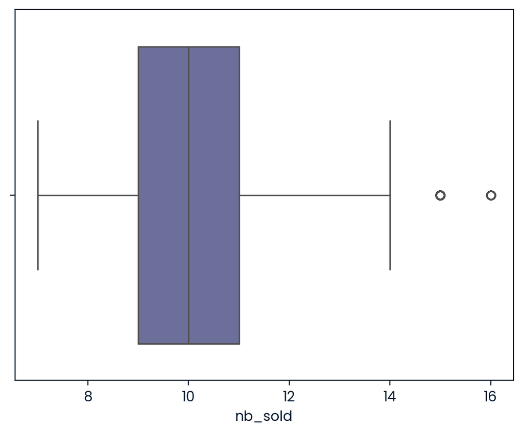

```python
sns.boxplot(data=df, x="nb_sold")
```

```python
df.info()
```

```
<class 'pandas.core.frame.DataFrame'>
Int64Index: 14998 entries, 0 to 14999
Data columns (total 8 columns):
 #   Column             Non-Null Count  Dtype
---  ------             --------------  -----
 0   week               14998 non-null  int64
 1   sales_method       14998 non-null  object
 2   customer_id        14998 non-null  object
 3   nb_sold            14998 non-null  int64
 4   revenue            14998 non-null  float64
 5   years_as_customer  14998 non-null  int64
 6   nb_site_visits     14998 non-null  int64
 7   state              14998 non-null  object
dtypes: float64(1), int64(4), object(3)
memory usage: 1.0+ MB
```

# EXPLORATORY ANALYSIS

## 1) Number of Customers per Sales Method

The most popular method of Sales in the 6 weeks period is by Email with 7465 customers, followed by Call with 4961 customers and Email + Call with 2572 customers. As email are much more easier to do, emails can be more scalable in comparison with other methods.

```python
#Some Customization
custom_order = ['Email', 'Call', 'Email + Call']
color = {'Email':'red', 'Call':'blue', 'Email + Call': 'green'}

cus = df.groupby('sales_method')['customer_id'].count().reset_index()
cus = pd.DataFrame(cus)

px.bar(cus, x="sales_method", y="customer_id", title = 'Number of Customers per Sales Method', labels={'sales_method': 'Sales Method', 'customer_id': 'Number of Customers'}, color = 'sales_method', color_discrete_map=color).show()
```

[interactive chart not shown]

## 2) Spread of Revenue (Overall and by Method)

```python
px.box(df, x="revenue", title="Spread of Revenue (Overall)").show()
```

[interactive chart not shown]

```python
px.box(df, x="revenue", y="sales_method", color="sales_method", title="Spread of Revenue (By Method)", color_discrete_map=color).show()
```

[interactive chart not shown]

Email (red): Has a relatively high median and wide range. Also shows many outliers above $130. Suggests that email can generate high revenue but with high variability.

Email + Call (green): Shows a tight cluster around the high revenue range ($150–$200), indicating it is consistently effective with high revenue per case and few low values. It also has a lot of outliers above $200.

Call (blue): Has the lowest median and narrowest spread, with revenue mostly between $30–$60. Indicates that calls alone tend to produce lower and more consistent revenue.

Email + Call is the best-performing method, with high and consistent revenue. Performs better than the overall.

Call-only performs the worst in terms of revenue. Performs worst than the overall.

Email-only has a broad distribution, capable of high revenue but with variability.

## 3) Number of Customers, Revenue, Sales Volume Over Time by Method

```python
revenue_weekly = df.groupby(['week'])['sales_method'].value_counts().reset_index(name='count')

revenue_weekly = pd.DataFrame(revenue_weekly)

px.line(revenue_weekly, x='week', y='count', color='sales_method', color_discrete_map=color, title='Number of Customers Reached by Each Method Over Time').show()
```

[interactive chart not shown]

```python
revenue_weekly = df.groupby(['week', 'sales_method'])['revenue'].sum().reset_index()

fig4 = px.line(revenue_weekly, x='week', y='revenue', color='sales_method',
              title='Revenue Over Time by Sales Method',
              labels={'week': 'Week Since Launch', 'revenue': 'Total Revenue'}, color_discrete_map=color).show()
```

[interactive chart not shown]

```python
sales_weekly = df.groupby(['week', 'sales_method'])['nb_sold'].sum().reset_index()

fig5 = px.line(sales_weekly, x='week', y='nb_sold', color='sales_method', color_discrete_map=color,
              title='Sales Volumn Over Time by Sales Method',
              labels={'week': 'Week Since Launch', 'nb_sold': 'Sales Volumn'}).show()
```

[interactive chart not shown]

Both Revenue and Sales Volumn Over Time line charts shows similar trends:

- In week 1, the 'Email' sales method generated the highest revenue ($248K, 24.6K Products), followed by 'Call' ($27K, 5.4K Products) and 'Email + Call' ($20K, 1.3K Products). However, it is important to note that the 'Email' method required the least effort from the sales team, making it the most efficient method during the first week hence more customers are notified through 'Email'.
- Over the course of the 6 weeks sales generated from the Email sales method consistently decreased. This decline in revenue overtime could indicate diminishing returns from the Email sales method as time goes on.
- This can be attributed to the decreasing of number of customers being reached by Emails and both Call and Email + Call surpassed Email in terms of customer outreach.
- The call method shows an overall incresing trend in revenue overtime with some fluctations. Towards the end of the 6 week period the amount of revenue generated from the Call method began to decrease. This follows the trend of number of customer reached closely, which means that Calls should be carried out consistently to maintain the revenue gathered from Calls.
- The Email + Call method shows a healthy increasing trend of revenue over the 6 week period. Just a small increase in customers reached by Email + Call leads to a quite significant increase in Revenue and Sales Volume.
- It's possible that this method would be the most beneficial in terms of long-term revenue growth compared to the two other sales methods.

In conclusion, the Email + Call sales method appears to be the most promising in terms of long-term revenue generation, although it does require more effort from the sales team compare to Emails. The Email method starts strong but shows a steady decline, while the Call method has an overall increasing trend but fluctuates more. It is recommended to consider the efficiency and effort required for each method while making a decision on which sales method to continue using.

## 4) More About Sales Methods

### A) Summary Table of Sales Method

```python
summary = df.groupby('sales_method').agg(
    total_customers=('customer_id', 'nunique'),
    total_revenue=('revenue', 'sum'),
    avg_revenue_per_customer=('revenue', lambda x: x.sum() / x.nunique()),
    avg_site_visits=('nb_site_visits', 'mean'),
    avg_years_as_customer=('years_as_customer', 'mean'),
    total_products_sold=('nb_sold', 'sum')
).round(2)

summary = summary.sort_values(by='total_revenue', ascending=False)

go.Figure(data=[go.Table(
    header=dict(values=['Sales Method'] + list(summary.columns)),
    cells=dict(values=[[i for i in summary.index]] + [summary[col].tolist() for col in summary.columns])
)]).show()
```

[interactive chart not shown]

### B) Number of Site Visits by Sales Method

```python
# Number of Site Visits by Sales Method
px.box(df, x="nb_site_visits", y="sales_method", color="sales_method", title="Number of Site Visits(By Method)", color_discrete_map=color).show()
```

[interactive chart not shown]

This boxplot shows that Email + Call method still performs best among the methods in increasing the numbers of site visits among customers contacted, with higher median and range than the other 2 methods.

### C) Customer Engagement

```python
CusEngage = round(df.groupby('sales_method')['nb_site_visits'].mean(), 2)
CusEngage = CusEngage.reset_index(name='Average Number of Site Visits')
print(CusEngage)

px.bar(CusEngage, x='sales_method', y='Average Number of Site Visits', color="sales_method", title="Customer Engagement (By Method)", color_discrete_map=color).show()
```

```
   sales_method  Average Number of Site Visits
0          Call                          24.42
1         Email                          24.75
2  Email + Call                          26.77
```

[interactive chart not shown]

Calculating a metric to gauge the Customer Engagement by each method still shows that Email + Call perform best at average number of site visits of 26.77 which is higher than Email (24.75) and Call (24.42).

### D) Number of Sales by Sales Method

```python
px.box(df, x="nb_sold", y="sales_method", color="sales_method", title="Number of New Products Sold (By Method)", color_discrete_map=color).show()
```

[interactive chart not shown]

From the boxplot, we show the Email + Call has the most of number of new products sold with median and range higher than the other two methods, which means that Email + Call method can make more customers to buy our new products than the other two.

### E) Conversion Efficiency

This metrics show for each sales method, what is the conversion efficiency of the number of site visits of a customer to the number of products sold.

```python
CE = round((df.groupby('sales_method')['nb_sold'].mean() /
      df.groupby('sales_method')['nb_site_visits'].mean()) * 100, 2)

CE = CE.reset_index(name='Conversion Efficiency')
print(CE)

px.bar(CE, x='sales_method', y='Conversion Efficiency',  color='sales_method', color_discrete_map=color, title='Conversion Efficiency of Different Sales Methods').show()
```

```
   sales_method  Conversion Efficiency
0          Call                  38.94
1         Email                  39.30
2  Email + Call                  45.67
```

[interactive chart not shown]

Quantifying this, the Conversion Efficiency of each method is calculated to investigate how effective each sales method in converting the number of site visits to the number of products sold among customer contacted. This shows that Email + Call has significant higher conversion efficiency at 45.67 than the other two, Call (38.94) and Email (39.3).

## 5) Revenue by States

```python
dfstate = df.groupby('state')['revenue'].sum().reset_index().sort_values(by='revenue', ascending=False)
px.bar(dfstate, x='state', y='revenue', title='Revenue by State',
              labels={'state': 'State', 'revenue': 'Revenue'}).show()
```

[interactive chart not shown]

From this barplot of Total Revenue vs State, we found out that our company earned the most revenue from California, Texas, New York and Florida which are all big states in terms of populations. So the sales team must concentrate in marketing in these states, especially the state of California.

## 6) Defining Business Metrics to Track Performance

### Define the sales effort for each sales method

| Sales Method | Description | Effort Score (0-10) |
| --- | --- | --- |
| Email | 2 emails | 1 |
| Call | 30 minute call | 6 |
| Email + Call | 1 email + 10 minute call | 3 |

**Average Revenue per Customer Sales Effort (ARCSE) = Total Revenue for Method / Number of customers * Sales effort**

```python
# Define the sales effort for each sales method
sales_effort = {
    'Email': 1,
    'Call': 6,
    'Email + Call': 3
}

# Group the data by sales_method and aggregate the total revenue and number of customers
df1 = df.groupby('sales_method').agg({'revenue': 'sum', 'customer_id': 'count'}).reset_index()

# Calculate ARCPSE for each sales method
df1['ARCSE'] = df1.apply(lambda row: row['revenue'] / (row['customer_id'] * sales_effort[row['sales_method']]), axis=1)

# Display the ARCPSE for each sales method
print(df1[['sales_method', 'ARCSE']])
```

```
   sales_method      ARCSE
0          Call   7.932815
1         Email  97.128009
2  Email + Call  61.217264
```

Email has the highest ARCSE (97.13) — it brings in the most revenue per unit of effort. So it is the most cost-effective among the 3 sales methods.

Email + Call has the second highest ARCSE (61.22) — moderate effort with solid returns.

Call alone is the least efficient (7.93), likely due to high time cost.

# CONCLUSION AND RECOMMENDATIONS

1. Email + Call is the Most Effective Overall
- Consistently high revenue with a tight distribution around high values (median ~ $150–$200).
- Highest customer engagement (avg. 26.77 site visits).
- Best conversion efficiency (45.67%) — converts visits into sales most effectively.
- Strong upward trend in revenue and sales over time.
- ARCSE of 61.22 suggests a solid return on moderate sales effort.

Insight: This method balances effectiveness and effort well. It’s highly engaging and reliable in driving both revenue and product sales.

Recommendation:

- Scale this method where possible.
- Automate the email step to reduce total effort per customer.
- Train sales teams for efficient, high-impact follow-up calls (~10 mins).
2. Email Alone is the Most Cost-Efficient (ARCSE Leader)
- Highest ARCSE (97.13) — outstanding revenue per unit of effort.
- High customer reach and early performance peak in Week 1.
- Declines in performance over time, likely due to saturation and declining customer responsiveness.
- Wide revenue range and many outliers — can generate very high returns for some customers.

Insight: Great for broad outreach and low-cost scalability. However, it lacks consistent long-term performance.

Recommendation:

- Use Email for initial outreach, especially for large or low-priority segments.
- Consider refreshing content or A/B testing email strategies to sustain engagement over time.
3. Call Only is the Least Efficient Method
- Lowest ARCSE (7.93) — low revenue per unit effort due to high time investment (30 mins/customer).
- Low median revenue, narrow range, and poor engagement metrics.
- Slight revenue increase in mid-weeks, but drops again toward end.

Insight: High-cost channel with limited return. May be useful only for very high-value accounts.

Recommendation:

- Limit to high-potential or strategic customers.
- Explore replacing or complementing calls with video demos, live webinars, or follow-up automation. Or just discard this method.
4. Geographic Focus — Prioritize Key States
- California, Texas, New York, and Florida drive the most revenue.
- These states also represent large customer bases with high conversion potential.

Recommendation:

- Concentrate sales and marketing efforts in these high-performing states.
- Use Email + Call to nurture high-value leads in these regions for better ROI.

### Summary

**"Combining email and calls generates the most consistent and high revenue, while calls alone yield the lowest returns. Although email-only has the highest number of interactions, it shows greater variability and less reliability in outcomes."**

### Business Strategy Recommendations

**Sales Method Strategy**: Expand Email + Call use; automate where possible

**Cost Efficiency**: Use Email-only for large-scale outreach with minimal human input

**Resource Allocation**: Restrict Call-only to VIP accounts or special cases

**Customer Engagement**: Monitor site visits & conversion to optimize message timing & content

**Regional Targeting**: Prioritize CA, TX, NY, FL for marketing & follow-up investments

```python
!jupyter nbconvert --to html --embed-images --execute notebook.ipynb
```

```
[NbConvertApp] Converting notebook notebook.ipynb to html
[NbConvertApp] Writing 1498685 bytes to notebook.html
```